# Coursera - Practical Machine Learning - assigment

Tomasz Dworowy

# Setup

```r
knitr::opts_chunk$set(warning=FALSE, message=FALSE)
```

Load libraries.

```r
if (!require("ggplot2"))
  install.packages("ggplot2")
library(ggplot2)
if (!require("caret"))
  install.packages("caret")
library(caret)
if (!require("parallel"))
  install.packages("parallel")
library(parallel)
if (!require("doParallel"))
  install.packages("doParallel")
library(doParallel)
```

Setup parallel data processing.

```r
cluster <- makeCluster(detectCores() - 1)
registerDoParallel(cluster)
```

Download data.

```r
traning_file <- "pml-training.csv"
testing_file <- "pml-testing.csv"
if(!file.exists(traning_file)) {
    download.file('https://d396qusza40orc.cloudfront.net/predmachlearn/pml-training.csv',
                  destfile = traning_file)}
if(!file.exists(testing_file)) {
  download.file('https://d396qusza40orc.cloudfront.net/predmachlearn/pml-testing.csv',
              destfile = testing_file)}
```

# Load and clear data

Load data

```r
traning <- read.csv(traning_file)
testing <- read.csv(testing_file)
```

Data Clean up * Remove columns witch NAs * Remove columns witch redundant data * split data to training and validation sets

```r
traning$classe <- as.factor(traning$classe)
traning <- Filter(function(x) !any(is.na(x)), traning)

traning_remove <- grepl("^X|timestamp|window", names(traning))
traning <- traning[, !traning_remove]

traning <- traning[,-nearZeroVar(traning)]

partitoin <- createDataPartition( y = traning$classe, p = 0.7, list = FALSE)

traning <- traning[partitoin,]
validation <- traning[-partitoin,]

testing <- testing[,names(traning[, which(names(traning) != "classe")])]
```

Use data subset (due performance problems)

```r
traning <- traning[sample(1:nrow(traning), 3000,
   replace=FALSE),]
```

# Background

Using devices such as Jawbone Up, Nike FuelBand, and Fitbit it is now possible to collect a large amount of data about personal activity relatively inexpensively. These type of devices are part of the quantified self movement – a group of enthusiasts who take measurements about themselves regularly to improve their health, to find patterns in their behavior, or because they are tech geeks. One thing that people regularly do is quantify how much of a particular activity they do, but they rarely quantify how well they do it. In this project, your goal will be to use data from accelerometers on the belt, forearm, arm, and dumbell of 6 participants. They were asked to perform barbell lifts correctly and incorrectly in 5 different ways. More information is available from the website here: http://groupware.les.inf.puc-rio.br/har (see the section on the Weight Lifting Exercise Dataset).

# Machine learning

```r
fitControl <- trainControl(method = "cv",
number = 5,
allowParallel = TRUE)
```

## Model 1 - random forest

First model - random forest.

```r
fit_rf <- train(classe ~., data = traning, method = 'rf', prox = TRUE, trControl = fitControl, ntree=250)
```

```r
predictions_rf <- predict(fit_rf, newdata = validation)
confusionMatrix(predictions_rf, validation$classe)
```

```
## Confusion Matrix and Statistics
##
##           Reference
## Prediction    A    B    C    D    E
##          A 1143   28    0    0    1
##          B    3  801   20    8    8
##          C    3   12  649   15    2
##          D    1    2    6  680    8
##          E    6    2    1    0  699
##
## Overall Statistics
##
##                Accuracy : 0.9693
##                  95% CI : (0.9635, 0.9743)
##     No Information Rate : 0.2821
##     P-Value [Acc > NIR] : < 2.2e-16
##
##                   Kappa : 0.9611
##
##  Mcnemar's Test P-Value : 3.867e-07
##
## Statistics by Class:
##
##                      Class: A Class: B Class: C Class: D Class: E
## Sensitivity            0.9888   0.9479   0.9601   0.9673   0.9735
## Specificity            0.9901   0.9880   0.9906   0.9950   0.9973
## Pos Pred Value         0.9753   0.9536   0.9530   0.9756   0.9873
## Neg Pred Value         0.9956   0.9865   0.9921   0.9932   0.9944
## Prevalence             0.2821   0.2062   0.1650   0.1715   0.1752
## Detection Rate         0.2789   0.1955   0.1584   0.1659   0.1706
## Detection Prevalence   0.2860   0.2050   0.1662   0.1701   0.1728
## Balanced Accuracy      0.9894   0.9680   0.9754   0.9811   0.9854
```

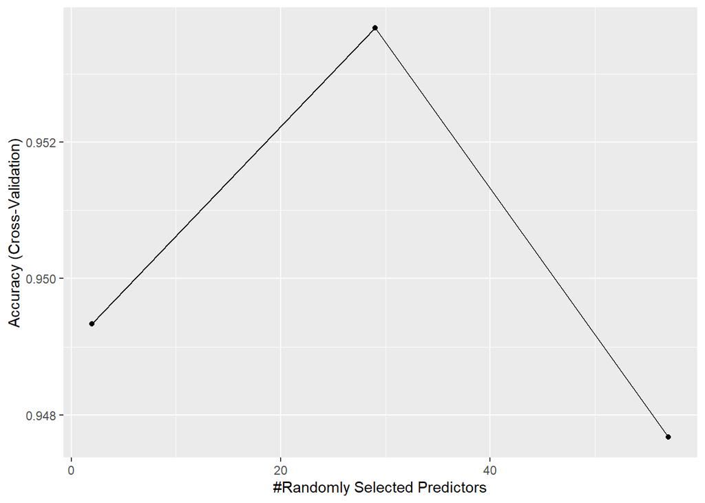

```r
ggplot(fit_rf)
```

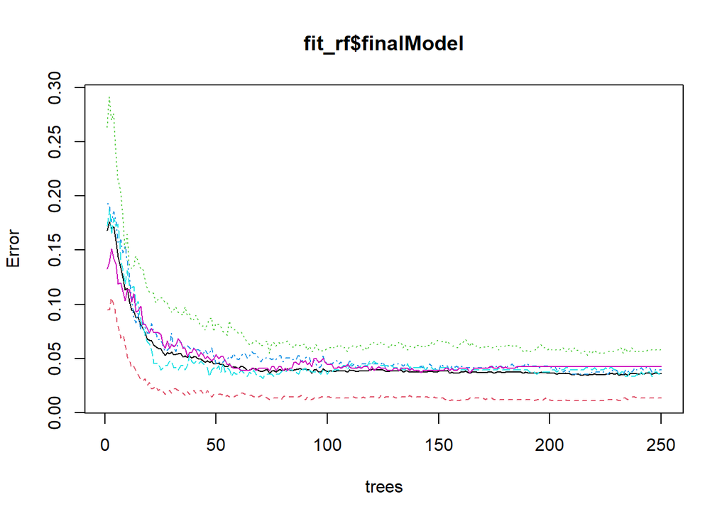

```r
plot(fit_rf$finalModel)
```

## Model 2 - Boosting

Second model - boosting.

```r
fit_gbm <- train(classe ~., data = traning, method = 'gbm', trControl = fitControl)
predictions_gbm <- predict(fit_gbm, newdata = validation)
confusionMatrix(predictions_gbm, validation$classe)
```

```
## Confusion Matrix and Statistics
##
##           Reference
## Prediction    A    B    C    D    E
##          A 1120   30    0    1    4
##          B   18  784   33    5   12
##          C    7   22  633   25   16
##          D    5    3    7  669   10
##          E    6    6    3    3  676
##
## Overall Statistics
##
##                Accuracy : 0.9473
##                  95% CI : (0.94, 0.9539)
##     No Information Rate : 0.2821
##     P-Value [Acc > NIR] : < 2.2e-16
##
##                   Kappa : 0.9333
##
##  Mcnemar's Test P-Value : 1.352e-05
##
## Statistics by Class:
##
##                      Class: A Class: B Class: C Class: D Class: E
## Sensitivity            0.9689   0.9278   0.9364   0.9516   0.9415
## Specificity            0.9881   0.9791   0.9795   0.9926   0.9947
## Pos Pred Value         0.9697   0.9202   0.9004   0.9640   0.9741
## Neg Pred Value         0.9878   0.9812   0.9873   0.9900   0.9877
## Prevalence             0.2821   0.2062   0.1650   0.1715   0.1752
## Detection Rate         0.2733   0.1913   0.1545   0.1633   0.1650
## Detection Prevalence   0.2818   0.2079   0.1715   0.1694   0.1694
## Balanced Accuracy      0.9785   0.9535   0.9580   0.9721   0.9681
```

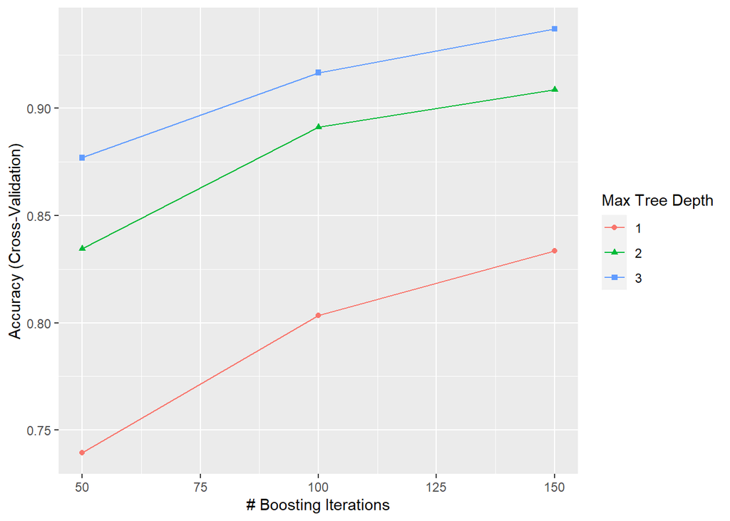

```r
ggplot(fit_gbm)
```

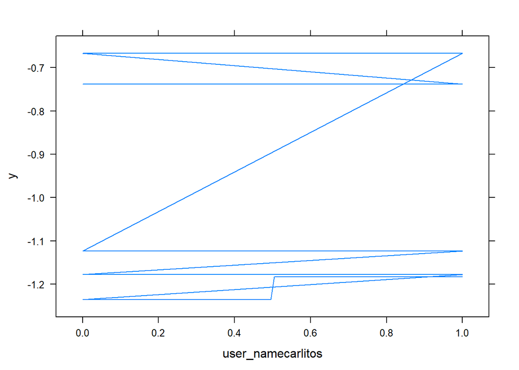

```r
plot(fit_gbm$finalModel)
```

## Predictions

Apply models to original testing data set.

```r
predictions_testing1 <- predict(fit_rf, newdata = testing)
predictions_testing1
```

```
##  [1] B A B A A E D B A A B C B A E E A B B B
## Levels: A B C D E
```

```r
predictions_testing2 <- predict(fit_gbm, newdata = testing)
predictions_testing2
```

```
##  [1] B A B A A E D B A A B C B A E E A B B B
## Levels: A B C D E
```